🦠 **Reviews in the Mid-Pandemic Era** 🦠

Sorted *Worst-Best:* Filtered for Time and Collaboration

**Professional training session**

**Facilitator**

**Date**

**Likeliness to Recommend**

**What could have improved your experience?**

**Likert Plot Ratings**

EL Virtual Bootcamp

Mandy

May, 19 2020

3

more collaborations with our own school...

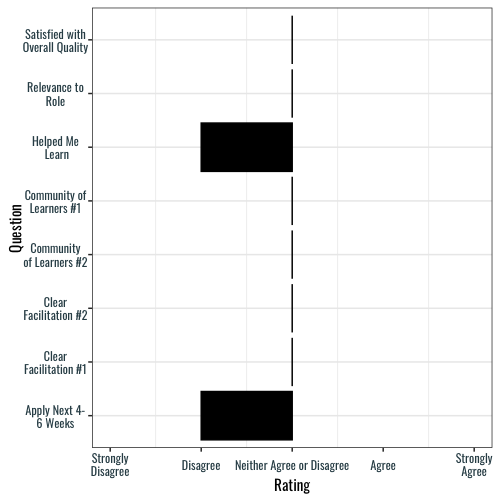

EL Virtual Bootcamp

Mandy

May, 19 2020

4

slowing down and more time to work within my grade level and talk with those teachers

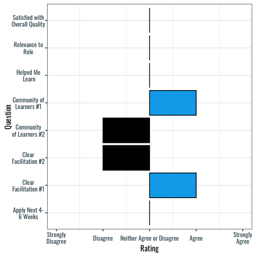

EL Virtual Bootcamp

Vaishali

May, 19 2020

6

More chance to collaborate with same grade-level teachers. More opportunity to investigate the material with classroom teachers and formulate questions that would need answering.

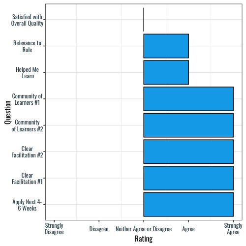

EL Virtual Bootcamp

Vaishali

May, 19 2020

6

A bit more time experiencing some of the activities that students will participate in.

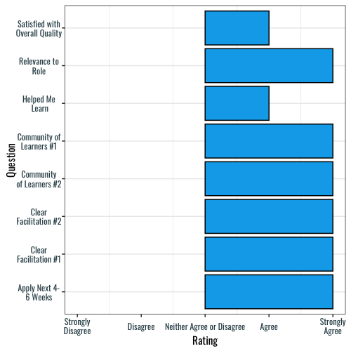

Guidebooks Diverse Learners Vocabulary, Day 1

Holli

Nov, 19 2020

6

more time with resources

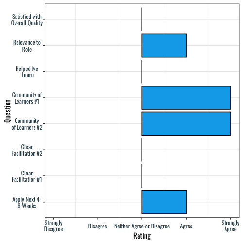

EL Virtual Bootcamp

Vaishali

May, 19 2020

8

Having more time to collaborate with fellow teachers.

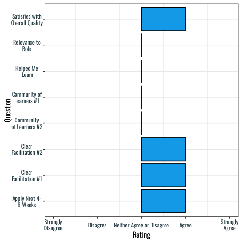

EL Virtual Bootcamp

Vaishali

May, 19 2020

8

More time to talk to grade level teachers

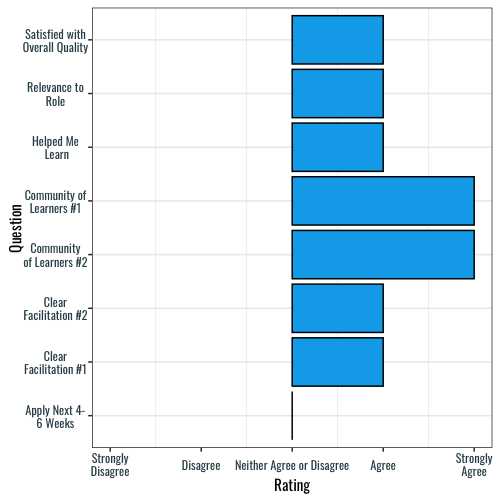

EL Virtual Bootcamp

Vaishali

May, 19 2020

8

Probably more time to dive in and an in person training but unfortunately we didn't have either of those opportunities

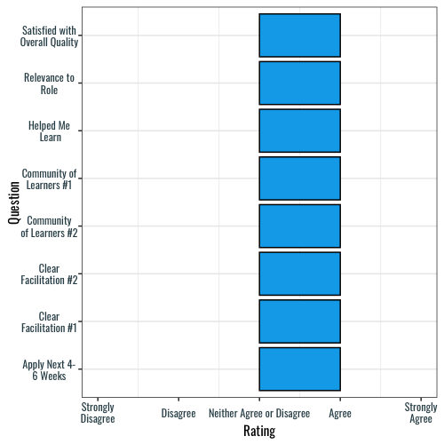

Guidebooks Diverse Learners Vocabulary, Day 1

Holli

Nov, 19 2020

8

More talking and time to collaborate and plan

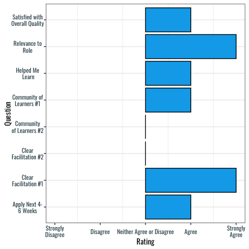

Guidebooks Diverse Learners Vocabulary, Day 1

Holli

Nov, 19 2020

8

More time to engage in discussion- not so heavy on the facilitator speaking and engaging everyone. Reflections & small group tasks would be helpful.

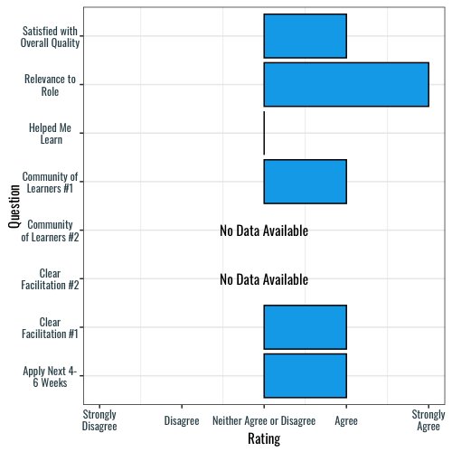